## Ternary Table

Our Plot Designation

Full Plot Name

Plot Description

Primary Literature

Image

QFL

QFL Provenance Diagram

This plot shows the provenance of a rock, broken into the mineral endmembers Quartz, Feldspar, and Lithics

Dickinson, W. R., & Suczek, C. A. (1979). Plate tectonics and sandstone compositions. Aapg Bulletin, 63(12), 2164-2182.

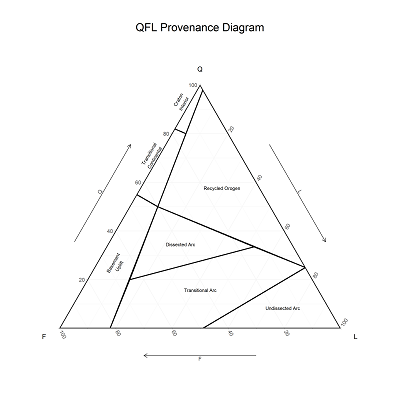

QFL2

QFL Classification Diagram

This plot shows the classification of a rock, broken into the mineral endmembers Quartz, Feldspar, and Lithics

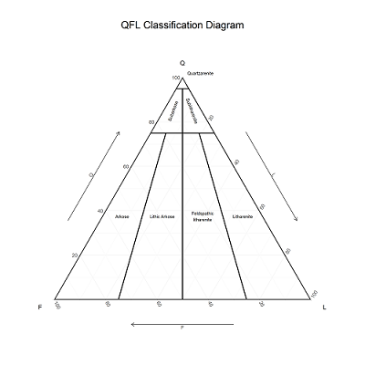

AFM

AFM Diagram

This plot shows the trends apparent in rocks formed in different environments, broken into the oxide endmembers Alkalis, Iron oxide, and Magnesium oxide

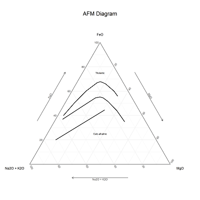

QAPi

QAP Diagram (Intrusive)

This plot shows the classification of an intrusive rock, broken into the mineral endmembers Quartz, Alkali feldspar, and Plagioclase

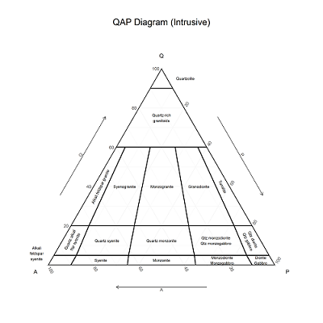

QAPe

QAP Diagram (Extrusive)

This plot shows the classification of an extrusive rock, broken into the mineral endmembers Quartz, Alkali feldspar, and Plagioclase

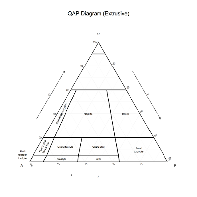

NFsp

Normative Quartz-rich Intrusive Igneous Rock Classification

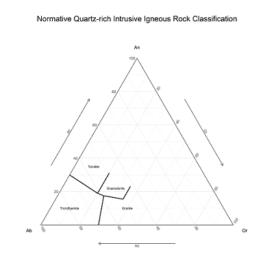

MFsp65

Modal Quartz-rich Intrusive Igneous Rock Classification

Oconnor, J. T. (1965). A classification for quartz-rich igneous rocks based on feldspar ratios. US Geological Survey Professional Paper B, 525, 79-84.

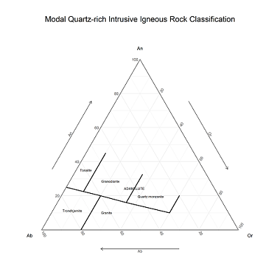

Nfsp65

Normative Quartz-rich Extrusive Igneous Rock Classification

Oconnor, J. T. (1965). A classification for quartz-rich igneous rocks based on feldspar ratios. US Geological Survey Professional Paper B, 525, 79-84.

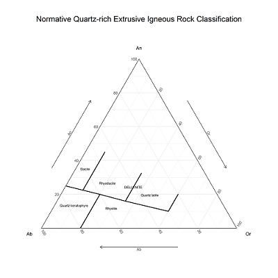

USDAsoils

USDA Textural Sediment Classification

This plot shows the sediment classification used by the United States Department of Agriculture

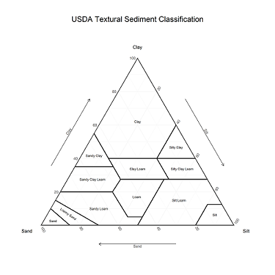

Shep

Shepard Sediment Classification

This plot shows Francis P. Shepard’s sediment classification, based on the ratios of sand, silt, and clay

Shepard, F.P. (1954). Nomenclature based on sand-silt-clay ratios: Journal of Sedimentary Petrology, 24, 151-158.

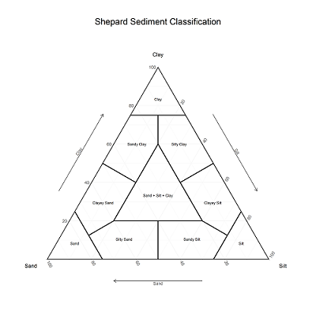

FspClass

Feldspar Classification Diagram

This plot shows the specific species determination of feldspar minerals, based on the mineral endmembers of Potassium feldspar, Sodium feldspar, and Calcium feldspar

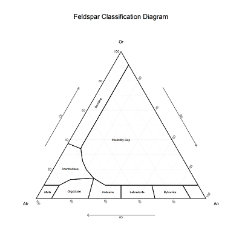